# Project 1: Wrangling, Exploration, Visualization

SDS322E

## Data Wrangling, Exploration, Visualization

### Layla Kutty lak2378

#### Introduction

I chose two movie related datasets that I found on Kaggle. The Disney data was obtained over the years by a student who researched the movies online up until 2016 and the IMDB data was taken from the IMDB website. data1 is a dataset of Disney movies that I found, and data2 is a list of IMDB’s top 1000 movies and shows based on their IMDB ratings. data1 has the title, genre, Motion Picture Association film rating, inflation adjusted gross, and total gross of that respective movie. data2 has the title, certificate, IMDB rating, meta score, director, number of votes, and gross income from that movie.

I am a huge movie lover so I thought this would be fun to do! Aside from that, I absolutely love Disney, so that is why I picked those specific movies to look at. I plan to figure out which of the Disney movies made it on to IMDB’s top 1000 movies/shows list. I’m excited to see what IMDB ratings the Disney movies on that list got.

```r
library(tidyverse)
data1 <- read_csv("disney_movies.csv")
data2 <- read_csv("imdb_top_1000.csv")
data1 <- data1 %>% rename(`gross(disney.data)` = "total.gross")
data2 <- data2 %>% rename(`gross(IMDB.data)` = "Gross")
```

#### Tidying: Reshaping

```r
# your tidying code (if applicable; can also wait until
# wrangling section)
```

I will be waiting until the wrangling section!

#### Joining/Merging including a discussion of how many observations/rows and distinct IDs were in each original dataset, which IDs appeared in one dataset but not the other, how many observations in each dataset were dropped (if any) after doing the join, and why you chose this particular join.

```r
# rename column in data2
data2 <- data2 %>% rename(movie.title = "Series.Title")
# joining the data
joined_data <- inner_join(data1, data2, by = "movie.title")
```

```r
# observations in each dataset and number of movies they
# share
nrow(data1)
```

```
## [1] 579
```

```r
nrow(data2)
```

```
## [1] 1000
```

```r
nrow(joined_data)
```

```
## [1] 50
```

```r
# number of dropped columns
nrow(data1) - nrow(joined_data)
```

```
## [1] 529
```

```r
nrow(data2) - nrow(joined_data)
```

```
## [1] 950
```

```r
# unique IDs in each dataset
data1 %>% summarise_all(n_distinct)
```

```
## # A tibble: 1 x 5
##   movie.title genre mpaa.rating `gross(disney.data)` inflation.adjusted.gross
##         <int> <int>       <int>                <int>                    <int>
## 1         573    13           6                  576                      576
```

```r
data2 %>% summarise_all(n_distinct)
```

```
## # A tibble: 1 x 7
##   movie.title Certificate IMDB.Rating Meta.score Director No.of.Votes
##         <int>       <int>       <int>      <int>    <int>       <int>
## 1         999          17          17         64      548         999
## # … with 1 more variable: `gross(IMDB.data)` <int>
```

```r
# appear in data1 but not data2
nrow(anti_join(data1, data2, by = c("movie.title")))
```

```
## [1] 529
```

```r
data1.not.data2 <- anti_join(data1, data2, by = c("movie.title"))
data1.not.data2
```

```
## # A tibble: 529 x 5
##    movie.title         genre   mpaa.rating `gross(disney.da… inflation.adjusted…
##    <chr>               <chr>   <chr>                   <dbl>               <dbl>
##  1 Snow White and the… Musical G                   184925485          5228953251
##  2 Pinocchio           Advent… G                    84300000          2188229052
##  3 Song of the South   Advent… G                    65000000          1078510579
##  4 Cinderella          Drama   G                    85000000           920608730
##  5 20,000 Leagues Und… Advent… <NA>                 28200000           528279994
##  6 Lady and the Tramp  Drama   G                    93600000          1236035515
##  7 Sleeping Beauty     Drama   <NA>                  9464608            21505832
##  8 101 Dalmatians      Comedy  G                   153000000          1362870985
##  9 The Absent Minded … Comedy  <NA>                 25381407           310094574
## 10 Babes in Toyland    Musical G                    10218316           124841160
## # … with 519 more rows
```

```r
# appear in data2 but not data1
nrow(anti_join(data2, data1, by = c("movie.title")))
```

```
## [1] 952
```

```r
data2.not.data1 <- anti_join(data2, data1, by = c("movie.title"))
data2.not.data1
```

```
## # A tibble: 952 x 7
##    movie.title Certificate IMDB.Rating Meta.score Director No.of.Votes
##    <chr>       <chr>             <dbl>      <dbl> <chr>          <dbl>
##  1 The Shawsh… A                   9.3         80 Frank D…     2343110
##  2 The Godfat… A                   9.2        100 Francis…     1620367
##  3 The Dark K… UA                  9           84 Christo…     2303232
##  4 The Godfat… A                   9           90 Francis…     1129952
##  5 12 Angry M… U                   9           96 Sidney …      689845
##  6 The Lord o… U                   8.9         94 Peter J…     1642758
##  7 Pulp Ficti… A                   8.9         94 Quentin…     1826188
##  8 Schindler'… A                   8.9         94 Steven …     1213505
##  9 Inception   UA                  8.8         74 Christo…     2067042
## 10 Fight Club  A                   8.8         66 David F…     1854740
## # … with 942 more rows, and 1 more variable: `gross(IMDB.data)` <dbl>
```

Before joining the two datasets, data1 had 579 observations and data2 had 1000 observations. After joining, the dataset was condensed to 50 observations. This is how many IDs the two datasets have in common, and is significantly smaller than the original two datasets. This is because 529 observations from data1 were dropped and 950 observations from data2 were dropped. This shouldn’t give me any problems because the joined dataset now only contains Disney movies that made the IMDB top 1000, no important movies were lost. Additionally, 529 of the IDs in data1 were not in data2 and 952 of the IDs in data2 were not in data1. To see which movies those were, the datasets data1.not.data2 and data2.not.data1 can be viewed. Lastly, there are 573 unique IDs in data1 and 999 unique IDs in data2.

In order to figure out which of the movies from my disney list made it on to the IMDB top 1000 list, I decided to use inner join. This would allow me to join the datasets by movie name, giving me a dataset with only the movies that were on both lists. I had to match the column names of both datasets first in order to join them. That is what my first line of code is.

#### Wrangling Using

```r
library(knitr)
library(gt)

# average gross profit in descending order
movies_average_gross <- joined_data %>% select(movie.title, `gross(disney.data)`,
    `gross(IMDB.data)`) %>% mutate(average_gross = (`gross(disney.data)` +
    `gross(IMDB.data)`)/2) %>% arrange(desc(average_gross))
# the quartile based on the average gross profit
ntile_gross <- movies_average_gross %>% mutate(avg_gross4tile = ntile(average_gross,
    4))
ntile_gross
```

```
## # A tibble: 50 x 5
##    movie.title    `gross(disney.d… `gross(IMDB.dat… average_gross avg_gross4tile
##    <chr>                     <dbl>            <dbl>         <dbl>          <int>
##  1 The Avengers          623279547        623279547    623279547               4
##  2 The Lion King         422780140        422783777    422781958.              4
##  3 Toy Story 3           415004880        415004880    415004880               4
##  4 Captain Ameri…        408084349        408084349    408084349               4
##  5 Finding Nemo          380529370        380843261    380686316.              4
##  6 Inside Out            356461711        356461711    356461711               4
##  7 Zootopia              341268248        341268248    341268248               4
##  8 Guardians of …        333172112        333176600    333174356               4
##  9 The Sixth Sen…        293506292        293506292    293506292               4
## 10 Up                    293004164        293004164    293004164               4
## # … with 40 more rows
```

```r
# average gross profit of movies with 'The' in the title
ntile_gross %>% group_by(movie.title) %>% filter(str_detect(movie.title,
    "The")) %>% summarise(average_gross)
```

```
## # A tibble: 19 x 2
## # Groups:   movie.title [17]
##    movie.title                         average_gross
##    <chr>                                       <dbl>
##  1 Captain America: The Winter Soldier    259756765
##  2 The Avengers                           623279547
##  3 The Count of Monte Cristo               54231083
##  4 The Help                               169706850.
##  5 The Incredibles                        261441092
##  6 The Insider                             28965197
##  7 The Jungle Book                        252922368.
##  8 The Jungle Book                        141843306
##  9 The Jungle Book                         93093284
## 10 The Kid                                 37569192
## 11 The Ladykillers                               NA
## 12 The Lion King                          422781958.
## 13 The Little Mermaid                     111543479
## 14 The Muppet Christmas Carol              27281507
## 15 The Nightmare Before Christmas          62745493
## 16 The Prestige                            53089891
## 17 The Royal Tenenbaums                    52358823
## 18 The Sixth Sense                        293506292
## 19 The Straight Story                       6200455
```

Because my datasets both reported gross for each of their movies, I thought it would be interesting to find the average of the two. In order to do this, I selected the important variables (title and gross for each dataset) and created a new variable known as average_gross using mutate and arranged it in descending order. Next, I wanted to see what quartile each movie’s gross landed in. In order to do this, I used the mutate function along with a dplyr vector function. Lastly I incorporated str_detect by finding the average gross for each movie that had “The” in the title.

```r
# summary statistics for numerical variables
statistics <- joined_data %>% select(`gross(disney.data)`, inflation.adjusted.gross,
    IMDB.Rating, Meta.score, No.of.Votes, `gross(IMDB.data)`) %>%
    na.omit() %>% summarise_each(funs(mean = mean, sd = sd, min = min,
    max = max, median = median))

stats_tidy1 <- statistics %>% gather(stat, val) %>% separate(stat,
    into = c("var", "stat"), sep = "_") %>% spread(stat, val) %>%
    select(var, mean, sd, min, max, median)

stats_tidy1 %>% gt %>% tab_header(title = md("**Summary Statistics**"),
    subtitle = md("Numeric Variables")) %>% tab_spanner(label = "Variables",
    columns = c("var", "mean", "sd", "min", "max", "median"))
```

**Summary Statistics**

Numeric Variables

| Variables var | Variables mean | Variables sd | Variables min | Variables max | Variables median |
| --- | --- | --- | --- | --- | --- |
| gross(disney.data) | 1.754555e+08 | 1.463704e+08 | 4496583.0 | 623279547.0 | 155774293.5 |
| gross(IMDB.data) | 1.733036e+08 | 1.423670e+08 | 4496583.0 | 623279547.0 | 141843612.0 |
| IMDB.Rating | 7.889583e+00 | 2.381128e-01 | 7.6 | 8.5 | 7.8 |
| inflation.adjusted.gross | 2.852512e+08 | 3.427423e+08 | 6194870.0 | 2187090808.0 | 220266922.0 |
| Meta.score | 7.654167e+01 | 1.262041e+01 | 47.0 | 96.0 | 77.0 |
| No.of.Votes | 4.445318e+05 | 3.254509e+05 | 28825.0 | 1260806.0 | 353880.0 |

```r
# counts for categorical variables
categorical_counts <- joined_data %>% group_by(mpaa.rating, genre,
    Director, Certificate) %>% summarise(n())
categorical_counts %>% kable()
```

| mpaa.rating | genre | Director | Certificate | n() |
| --- | --- | --- | --- | --- |
| G | Adventure | Andrew Stanton | U | 1 |
| G | Adventure | Hayao Miyazaki | U | 1 |
| G | Adventure | John Lasseter | U | 2 |
| G | Adventure | Lee Unkrich | U | 1 |
| G | Adventure | Pete Docter | U | 1 |
| G | Adventure | Roger Allers | U | 1 |
| G | Adventure | Ron Clements | U | 1 |
| G | Adventure | Tony Bancroft | U | 1 |
| G | Comedy | Brad Bird | U | 1 |
| G | Comedy | Brian Henson | G | 1 |
| G | Comedy | Ron Clements | U | 1 |
| G | Drama | David Lynch | U | 1 |
| G | Musical | Gary Trousdale | G | 1 |
| G | Musical | James Algar | G | 1 |
| Not Rated | Musical | Wolfgang Reitherman | U | 1 |
| PG | Adventure | Brad Bird | U | 1 |
| PG | Adventure | Byron Howard | U | 1 |
| PG | Adventure | Don Hall | U | 1 |
| PG | Adventure | Hayao Miyazaki | U | 1 |
| PG | Adventure | Nathan Greno | U | 1 |
| PG | Adventure | Pete Docter | U | 2 |
| PG | Adventure | Rich Moore | U | 1 |
| PG | Adventure | Ron Clements | U | 1 |
| PG | Adventure | Wolfgang Reitherman | U | 2 |
| PG | Comedy | Charles Chaplin | Passed | 1 |
| PG | Drama | Boaz Yakin | U | 1 |
| PG | Drama | Peter Weir | U | 1 |
| PG | Musical | Henry Selick | U | 1 |
| PG-13 | Action | Anthony Russo | UA | 2 |
| PG-13 | Action | Joss Whedon | UA | 1 |
| PG-13 | Adventure | James Gunn | UA | 1 |
| PG-13 | Comedy | Joel Coen | U | 1 |
| PG-13 | Drama | Kevin Reynolds | PG-13 | 1 |
| PG-13 | Drama | Tate Taylor | UA | 1 |
| PG-13 | Thriller/Suspense | Christopher Nolan | U | 1 |
| PG-13 | Thriller/Suspense | M. Night Shyamalan | A | 1 |
| PG-13 | Thriller/Suspense | Steven Spielberg | UA | 1 |
| R | Adventure | Mel Gibson | A | 1 |
| R | Black Comedy | Wes Anderson | A | 1 |
| R | Black Comedy | Wes Anderson | UA | 1 |
| R | Comedy | Alexander Mackendrick | NA | 1 |
| R | Comedy | Tim Burton | U | 1 |
| R | Drama | Michael Mann | UA | 1 |
| R | Drama | Spike Lee | R | 1 |
| R | Western | George P. Cosmatos | R | 1 |
| R | NA | Taylor Hackford | R | 1 |

```r
# number of NAs for each variable
na_stat <- joined_data %>% summarise_all(funs(sum(is.na(.))))
na_stat %>% kable()
```

| movie.title | genre | mpaa.rating | gross(disney.data) | inflation.adjusted.gross | Certificate | IMDB.Rating | Meta.score | Director | No.of.Votes | gross(IMDB.data) |
| --- | --- | --- | --- | --- | --- | --- | --- | --- | --- | --- |
| 0 | 1 | 0 | 0 | 0 | 1 | 0 | 1 | 0 | 0 | 1 |

```r
# statistics with grouping by genre and mpaa_rating
grouping_genre_mpaa <- joined_data %>% group_by(genre, mpaa.rating) %>%
    summarise_each(funs(mean), `gross(disney.data)`, inflation.adjusted.gross,
        IMDB.Rating, Meta.score, No.of.Votes, `gross(IMDB.data)`)

grouping_genre_mpaa %>% gt %>% tab_header(title = md("**Summary Statistics**"),
    subtitle = md("Grouped By Genre and MPAA Rating")) %>% tab_spanner(label = "Variables",
    columns = c("genre", "mpaa.rating", "gross(disney.data)",
        "inflation.adjusted.gross", "IMDB.Rating", "Meta.score",
        "No.of.Votes", "gross(IMDB.data)"))
```

**Summary Statistics**

Grouped By Genre and MPAA Rating

| Variables mpaa.rating | Variables gross(disney.data) | Variables inflation.adjusted.gross | Variables IMDB.Rating | Variables Meta.score | Variables No.of.Votes | Variables gross(IMDB.data) |
| --- | --- | --- | --- | --- | --- | --- |
| Action |  |  |  |  |  |  |
| PG-13 | 430370285 | 445392883 | 7.833333 | 71.33333 | 886879.0 | 430376823 |
| Adventure |  |  |  |  |  |  |
| G | 243626707 | 374625155 | 8.000000 | 86.33333 | 611000.8 | 243716747 |
| PG | 229461293 | 248250584 | 7.863636 | 78.00000 | 434503.8 | 218373021 |
| PG-13 | 333172112 | 343771168 | 8.000000 | 76.00000 | 1043455.0 | 333176600 |
| R | 50866635 | 64959548 | 7.800000 | 68.00000 | 291018.0 | 50866635 |
| Black Comedy |  |  |  |  |  |  |
| R | 34729428 | 52575356 | 7.650000 | 81.00000 | 218035.5 | 34734614 |
| Comedy |  |  |  |  |  |  |
| G | 150359127 | 250114242 | 7.900000 | 82.00000 | 355262.7 | 150359127 |
| PG | 69688384 | 108993148 | 8.300000 | NA | 113314.0 | 5450000 |
| PG-13 | 45506619 | 67922002 | 7.700000 | 69.00000 | 286742.0 | 45512588 |
| R | 22760302 | 32962114 | 7.750000 | 80.50000 | 95700.5 | NA |
| Drama |  |  |  |  |  |  |
| G | 6197866 | 10111144 | 8.000000 | 86.00000 | 82002.0 | 6203044 |
| PG | 105757434 | 191636998 | 7.950000 | 63.50000 | 311773.0 | 105757434 |
| PG-13 | 111966846 | 129543528 | 7.900000 | 61.50000 | 278771.5 | 111971087 |
| R | 21024896 | 33059838 | 7.700000 | 76.00000 | 164797.0 | 21013020 |
| Musical |  |  |  |  |  |  |
| G | 151135812 | 1275054238 | 7.850000 | 95.50000 | 252920.0 | 147687858 |
| Not Rated | 141843000 | 789612346 | 7.600000 | 65.00000 | 166409.0 | 141843612 |
| PG | 50408318 | 100026637 | 8.000000 | 82.00000 | 300208.0 | 75082668 |
| Thriller/Suspense |  |  |  |  |  |  |
| PG-13 | 139636646 | 208676130 | 8.066667 | 70.33333 | 796497.0 | 139636646 |
| Western |  |  |  |  |  |  |
| R | 56505065 | 115781734 | 7.800000 | 50.00000 | 126871.0 | 56505065 |
| NA |  |  |  |  |  |  |
| R | 4496583 | 9156084 | 8.000000 | 47.00000 | 28825.0 | 4496583 |

```r
# statistics with grouping by director and certificate
grouping_direct_cert <- joined_data %>% group_by(Director, Certificate) %>%
    summarise_each(funs(mean), `gross(disney.data)`, inflation.adjusted.gross,
        IMDB.Rating, Meta.score, No.of.Votes, `gross(IMDB.data)`)

grouping_direct_cert %>% gt %>% tab_header(title = md("**Summary Statistics**"),
    subtitle = md("Grouped By Director and Certificate")) %>%
    tab_spanner(label = "Variables", columns = c("Director",
        "Certificate", "gross(disney.data)", "inflation.adjusted.gross",
        "IMDB.Rating", "Meta.score", "No.of.Votes", "gross(IMDB.data)"))
```

**Summary Statistics**

Grouped By Director and Certificate

| Variables Certificate | Variables gross(disney.data) | Variables inflation.adjusted.gross | Variables IMDB.Rating | Variables Meta.score | Variables No.of.Votes | Variables gross(IMDB.data) |
| --- | --- | --- | --- | --- | --- | --- |
| Alexander Mackendrick |  |  |  |  |  |  |
| NA | 39692139 | 53881593 | 7.700000 | 91.0 | 26464.0 | NA |
| Andrew Stanton |  |  |  |  |  |  |
| U | 380529370 | 518148559 | 8.100000 | 90.0 | 949565.0 | 380843261 |
| Anthony Russo |  |  |  |  |  |  |
| UA | 333915654 | 338048712 | 7.750000 | 72.5 | 699915.5 | 333925460 |
| Boaz Yakin |  |  |  |  |  |  |
| U | 115654751 | 180742479 | 7.800000 | 48.0 | 198089.0 | 115654751 |
| Brad Bird |  |  |  |  |  |  |
| U | 233943373 | 303722320 | 8.000000 | 93.0 | 649346.0 | 233943373 |
| Brian Henson |  |  |  |  |  |  |
| G | 27281507 | 55417615 | 7.700000 | 64.0 | 50298.0 | 27281507 |
| Byron Howard |  |  |  |  |  |  |
| U | 341268248 | 341268248 | 8.000000 | 78.0 | 434143.0 | 341268248 |
| Charles Chaplin |  |  |  |  |  |  |
| Passed | 69688384 | 108993148 | 8.300000 | NA | 113314.0 | 5450000 |
| Christopher Nolan |  |  |  |  |  |  |
| U | 53089891 | 68289913 | 8.500000 | 66.0 | 1190259.0 | 53089891 |
| David Lynch |  |  |  |  |  |  |
| U | 6197866 | 10111144 | 8.000000 | 86.0 | 82002.0 | 6203044 |
| Don Hall |  |  |  |  |  |  |
| U | 222527828 | 229249222 | 7.800000 | 74.0 | 410983.0 | 222527828 |
| Gary Trousdale |  |  |  |  |  |  |
| G | 218951625 | 363017667 | 8.000000 | 95.0 | 417178.0 | 218967620 |
| George P. Cosmatos |  |  |  |  |  |  |
| R | 56505065 | 115781734 | 7.800000 | 50.0 | 126871.0 | 56505065 |
| Hayao Miyazaki |  |  |  |  |  |  |
| U | 9900427 | 11578238 | 7.950000 | 83.0 | 229616.0 | 9900748 |
| Henry Selick |  |  |  |  |  |  |
| U | 50408318 | 100026637 | 8.000000 | 82.0 | 300208.0 | 75082668 |
| James Algar |  |  |  |  |  |  |
| G | 83320000 | 2187090808 | 7.700000 | 96.0 | 88662.0 | 76408097 |
| James Gunn |  |  |  |  |  |  |
| UA | 333172112 | 343771168 | 8.000000 | 76.0 | 1043455.0 | 333176600 |
| Joel Coen |  |  |  |  |  |  |
| U | 45506619 | 67922002 | 7.700000 | 69.0 | 286742.0 | 45512588 |
| John Lasseter |  |  |  |  |  |  |
| U | 218824206 | 387430028 | 8.100000 | 91.5 | 707470.5 | 218824206 |
| Joss Whedon |  |  |  |  |  |  |
| UA | 623279547 | 660081224 | 8.000000 | 69.0 | 1260806.0 | 623279547 |
| Kevin Reynolds |  |  |  |  |  |  |
| PG-13 | 54228104 | 78682079 | 7.800000 | 61.0 | 129022.0 | 54234062 |
| Lee Unkrich |  |  |  |  |  |  |
| U | 415004880 | 443408255 | 8.200000 | 92.0 | 757032.0 | 415004880 |
| M. Night Shyamalan |  |  |  |  |  |  |
| A | 293506292 | 485424724 | 8.100000 | 64.0 | 911573.0 | 293506292 |
| Mel Gibson |  |  |  |  |  |  |
| A | 50866635 | 64959548 | 7.800000 | 68.0 | 291018.0 | 50866635 |
| Michael Mann |  |  |  |  |  |  |
| UA | 28965197 | 47794214 | 7.800000 | 84.0 | 159886.0 | 28965197 |
| Nathan Greno |  |  |  |  |  |  |
| U | 200821936 | 214388548 | 7.700000 | 71.0 | 405922.0 | 200821936 |
| Pete Docter |  |  |  |  |  |  |
| U | 312963100 | 367290524 | 8.133333 | 87.0 | 789080.0 | 313127377 |
| Peter Weir |  |  |  |  |  |  |
| U | 95860116 | 202531517 | 8.100000 | 79.0 | 425457.0 | 95860116 |
| Rich Moore |  |  |  |  |  |  |
| U | 189412677 | 200354959 | 7.700000 | 72.0 | 380195.0 | 189422889 |
| Roger Allers |  |  |  |  |  |  |
| U | 422780140 | 761640898 | 8.500000 | 88.0 | 942045.0 | 422783777 |
| Ron Clements |  |  |  |  |  |  |
| U | 191658576 | 303925740 | 7.733333 | 85.0 | 294775.0 | 192550247 |
| Spike Lee |  |  |  |  |  |  |
| R | 13084595 | 18325463 | 7.600000 | 68.0 | 169708.0 | 13060843 |
| Steven Spielberg |  |  |  |  |  |  |
| UA | 72313754 | 72313754 | 7.600000 | 81.0 | 287659.0 | 72313754 |
| Tate Taylor |  |  |  |  |  |  |
| UA | 169705587 | 180404976 | 8.000000 | 62.0 | 428521.0 | 169708112 |
| Taylor Hackford |  |  |  |  |  |  |
| R | 4496583 | 9156084 | 8.000000 | 47.0 | 28825.0 | 4496583 |
| Tim Burton |  |  |  |  |  |  |
| U | 5828466 | 12042634 | 7.800000 | 70.0 | 164937.0 | 5887457 |
| Tony Bancroft |  |  |  |  |  |  |
| U | 120620254 | 216807832 | 7.600000 | 71.0 | 256906.0 | 120620254 |
| Wes Anderson |  |  |  |  |  |  |
| A | 52353636 | 76758193 | 7.600000 | 76.0 | 266842.0 | 52364010 |
| UA | 17105219 | 28392518 | 7.700000 | 86.0 | 169229.0 | 17105219 |
| Wolfgang Reitherman |  |  |  |  |  |  |
| U | 183395693 | 414181263 | 7.600000 | 65.0 | 166409.0 | 141843612 |

```r
# using my own function
naprop <- function(x) {
    sum(is.na(x))/length(x)
}
proportion_NA <- joined_data %>% summarise_all(naprop)

proportion_NA %>% kable()
```

| movie.title | genre | mpaa.rating | gross(disney.data) | inflation.adjusted.gross | Certificate | IMDB.Rating | Meta.score | Director | No.of.Votes | gross(IMDB.data) |
| --- | --- | --- | --- | --- | --- | --- | --- | --- | --- | --- |
| 0 | 0.02 | 0 | 0 | 0 | 0.02 | 0 | 0.02 | 0 | 0 | 0.02 |

In order to compute summary statistics of each of my numeric variables, I selected each variable and used summarise_each() to compute each statistic for the variables. I then tidied this data by gathering the data into stat and val columns, separating the stat column into var and stat columns, and then spread the data so that each variable I selected had a different column. I then found the counts of each level for my categorical variables by grouping by them and then using summarise(n()). I also got summary statistics for these variables after grouping by categorical variables by grouping and then using summarise_each() to find the mean of the variables I wanted. To count the number of NA’s for each variable, I summarised the sum of the NAs across all columns using summarise_all(). Lastly, I used my function to calculate the proportion of NAs in each variable.

After looking at the table grouped by MPAA ratings and Genre, I thought it was interesting that across all of the genres, they all had a range of IMDB ratings. None of them seemed to have a higher overall rating. Additionally, no MPAA Rating had a specific IMDB rating, they ranged from low to high. One last thing I noticed was that PG-13 movies tended to have lower meta score ratings and G movies had higher meta score ratings. I didn’t see any particular relationship between genre or rating and gross. These were just a few of the things I saw!

#### Visualizing

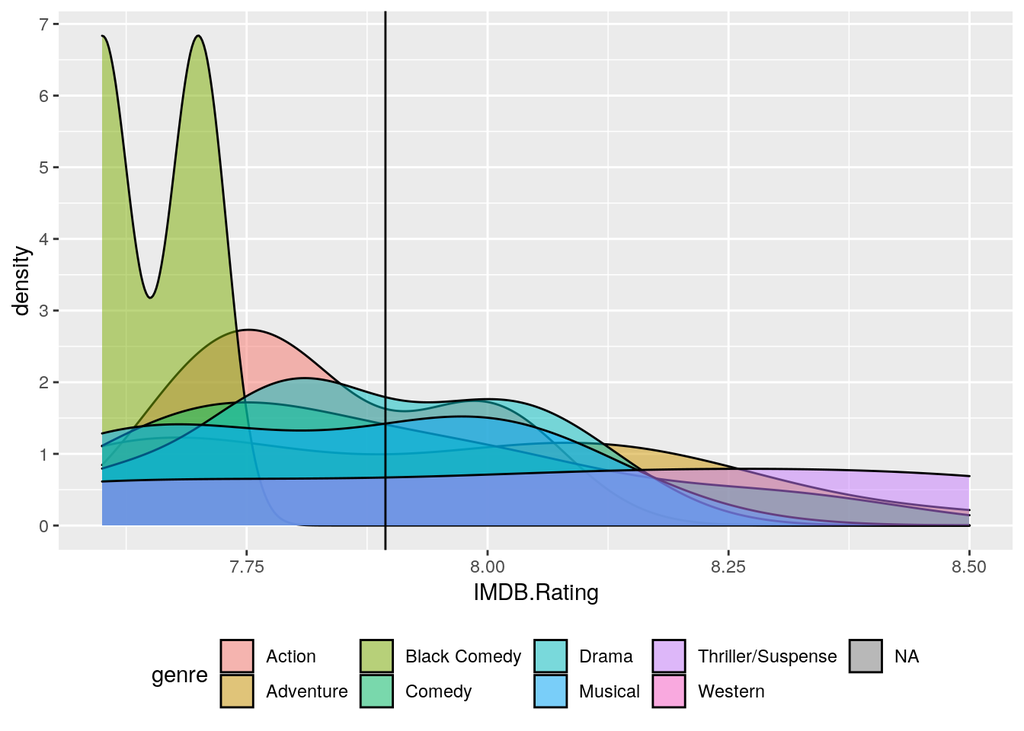

```r
ggplot(joined_data, aes(x = IMDB.Rating, fill = genre)) + geom_density(alpha = 0.5) +
    geom_vline(aes(xintercept = mean(IMDB.Rating))) + theme(legend.position = "bottom") +
    scale_y_continuous(breaks = seq(0, 7, 1))
```

In plot 1, we are able to see the overall IMDB ratings for each respective genre. For the most part, it seems that all of the genres seem to have gotten IMDB ratings spread across the minimum rating to the maximum. Something that does stand out is that the Black Comedy genre seems to have received only lower IMDB ratings. This may be due to the fact that there was only a few movies with that genre, so there aren’t many ratings to go off of. Additionally, I added a vertical line where the overall mean IMDB rating was. This allowed me to visualize how each genre’s IMDB ratings compared to the average rating.

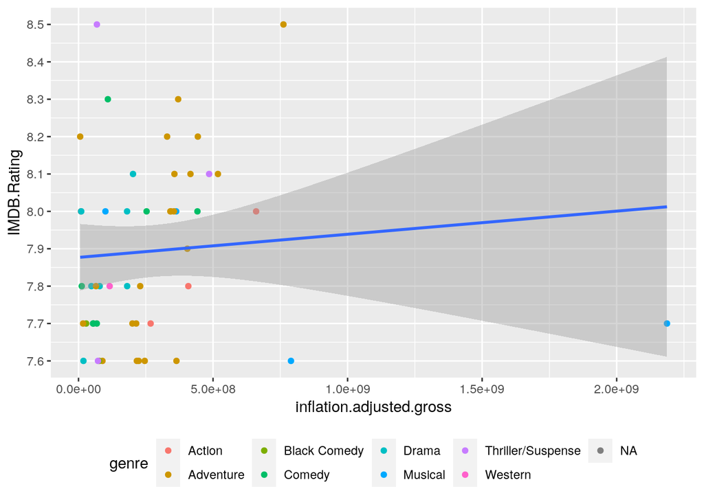

```r
ggplot(joined_data, aes(inflation.adjusted.gross, IMDB.Rating)) +
    geom_point(aes(color = genre)) + geom_smooth(method = "lm") +
    theme(legend.position = "bottom") + scale_y_continuous(breaks = seq(6,
    9, 0.1))
```

In plot 2, we are able to see the relationship between the IMDB rating, and the inflation adjusted gross for that movie. Additionally, I colored the points by the genre, so I could see if any particular genre had a higher inflation adjusted gross. When looking at the graph, we can see that there does not seem to be a relationship between the rating the movie received and the amount of money it brought in. I find this very interesting! Lastly, it seems as if the adventure genre sits in the higher range of inflation adjusted gross. Maybe those movies tend to do better!

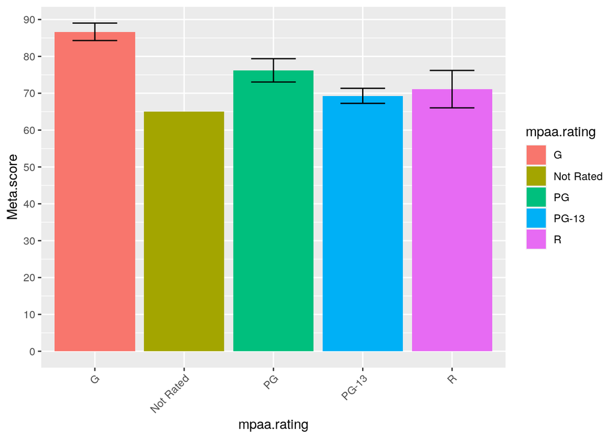

```r
ggplot(joined_data, aes(x = mpaa.rating)) + geom_bar(aes(y = Meta.score,
    fill = mpaa.rating), stat = "summary", fun = mean) + geom_errorbar(aes(x = mpaa.rating,
    y = Meta.score), stat = "summary", width = 0.5) + theme(axis.text.x = element_text(angle = 45,
    hjust = 1), legend.position = "right") + scale_y_continuous(breaks = seq(0,
    100, 10))
```

In plot 3, I looked at the MPAA rating compared to the average Meta Score for that rating. After analyzing the graph, it seems that across all of the ratings (G, Not Rated, PG, PG-13, R), the Not Rated movies had the most unfavorable reviews compared to the others and the G rated movies had the most favorable reviews (that is what a meta score is). The other movies fell somewhere between those. Maybe because G rated movies apply to a greater audience, they had better reviews.

#### Concluding Remarks

If any!